# Exploratory Analysis - Messages of Dress Codes

Yicai Liu, Chloe Chen, Alexander Zhang

Spring, 2022-05-16

## Abstract

Analyzing implications of and bias in public high school dress codes in the US.

## Key words

Clothing, School, Banned, Objectification, Gender & Racial Bias

## Introduction

Our research project explores the social implications of banned dress items/dress codes by analyzing banned clothing data across public high schools in the US. Clothing is a way for students to dictate how they look to others and are a way for them to express themselves. Restrictive dress codes and banned items put power in the hands of the schools to control how students (especially female students) dress, leaving room for bias regarding what is or isn’t allowed. Some research questions include some trends of commonly banned dress items, are there any similarities in dress codes among high schools in the same state or region, differences between dress codes for boys and girls, and what impacts these dress codes have on students.

These questions are important because they highlight the reason for these dress codes. In many schools, dress codes are in place to enforce the order by normalizing what students look like in order to create a safe learning environment. However, the reasons can vary in different schools and school districts. Our research project seeks to use trends in school dress code data in order to find whether this order is needed for the school to succeed or whether it enforces gender norms and stereotypes by sexualizing female clothing.

## Related Work

Much of the other work on the topic of dress codes in high schools relates to bias against girls and objectification of female students through their clothing. County school data from St. Johns County showed that 83% of dress code violations were for girls over a year. Although the dress codes apply to boys and girls, the most significant and most common violations were for girls. The dress codes themselves were also biased towards stereotypical gender norms, with boys wearing pants and girls wearing skirts. However, many problems arise when forcing such restrictive rules on clothing, such as girls not feeling safe or not being able to find clothing that fits the dress code.

The articles expose a big problem of the objectification of girls, with schools blaming “unsafe” learning conditions on their clothing because of reasons such as certain items of clothing being too sexual. This forces problem from the people who view the clothing sexually, such as male students or teachers, onto the female students. Much of the consensus on the topic of banned clothing items and dress codes is that it targets girls and their clothing, perpetuating harmful gender stereotypes and causing problems for female students such as lowered confidence and sexual objectification.

Citations: “School Dress Codes Present Double Standard.” New Jersey State Bar Foundation, 20 Oct. 2020, https://njsbf.org/2020/10/20/school-dress-codes-present-double-standard/.

Shields, Author: Leah. “Public Records Show More Dress Code Violations for Female Students in St. Johns County Schools.” Firstcoastnews.com, 12 Apr. 2021, https://www.firstcoastnews.com/article/entertainment/television/programs/gmj/public-records-disproportionate-dress-code-violations-female-students-st-johns-county-schools/77-a2bd2163-f28d-427b-9815-7e9b8b5c8cd1

Lim, Heejin, et al. “Objectification Found in High School Girls’ Experience With Dress Code Enforcement.” Clothing and Textiles Research Journal, Nov. 2021, doi:10.1177/0887302X211058434. [Link](https://journals.sagepub.com/doi/full/10.1177/0887302X211058434)

## The Dataset

We found the dataset here: [Dress codes](https://github.com/the-pudding/data/tree/master/dress-codes)

The data was collected by Amber Thomas with data collection assistance from Kait Thomas and Anna Houston. The data scientists manually visited 2,000+ websites to find the dress code. Dress codes were not included in the analysis if they: had a uniform policy, were not from the 2018-2019 school year, or represented magnet or boarding schools (according to the NCES).

Only items and body parts that were explicitly listed were included in this analysis. Some minor subjectivity came into play when combining similar phrases from different handbooks (ex. “midriff shirt” = “crop top”, “shirt with open sides” = “muscle shirt” etc.).

To define which items listed in the dress codes were marketed to girls, boys, or any student, the data scientists are looking for each item or item attribute in the 5 most popular teen clothing brands’ websites: Nike, American Eagle, Adidas, Forever 21, and Urban Outfitters. If items or styles appeared in more than twice as many stores for one gender over another, the item was considered to be primarily marketed to that gender.

The data was collected to learn about what public high schools in the U.S. prohibit in their dress codes, why these policies on dress codes exist, and what message is expressed to students in the dress codes policies. There are 15145 observations and 5 features in the data.

Questions about how dress codes implicitly refer to certain gender or race of students and who determines whether or not a student violates the dress code should be considered. One problem with this dataset would be the wording: “none” used in the feature “prohibited” to describe “No specific gender banned from wearing item.”

## Implications

Assuming we answer our research questions, possible implications for *technologists* could be filtering and making a more accessible database or website for people to browse. To concentrate the database and make the database more accessible for people to understand the meaning behind the data. Possible implications for *designers* could be designing more female clothes with more variety and options and creating more posters or public service announcements in order for people to pay attention to the importance of sexism and how dress codes sexualize students. Spread the awareness of gender equality and sexism through publications and media such as films, comics and stories. Possible implications for *policymakers* could be to take more suggestions from the National Women’s Law Center and Oregon NOW to create a model dress code policy to help schools create more applicable rules related to dress codes for all students that enhance gender and racial equality. They are also setting up policies about mental health education for early students and strengthening their knowledge about gender and sex.

## Challenges & Limitations

Some of the limitations we might need to address when working on the project are the missing enforcement of the school’s subjective policies. The previous data can give an idea of how bias can influence policies. Thus, the additional enforcement of policies should explain more information. Moreover, it should generate a more thorough report. Another limitation can be the word count for the data set. There can be more word count in the data set for describing boys’ or girls’ bodies and clothes. However, counting more words in the data set can be a real challenge for collecting such a huge sample. On the other hand, the data might be biased based on such a large number. Moreover, students’ ideas of the dressing code can also be critical in our project idea. To show the percentage of students who hold positive or negative attitudes on specific dressing codes and why they hold such attitudes. Thus, collecting data on keywords relates to students’ attitudes would add credence to the data set, and make the voice of those who are actually subjected to the dress codes heard.

## Table

| Item | How many schools banned this item |
| --- | --- |
| alcohol | 410 |
| drugs | 370 |
| disruption/distraction | 367 |
| tobacco | 347 |
| midsection midriff | 340 |
| short shorts | 334 |
| visible | 332 |
| appropriate/inappropriate | 330 |
| hats | 329 |
| safe/safety | 315 |

## Chart 1

Bar Chart displaying the top 10 banned items in high schools across the US, showing which items were most commonly banned. The chart shows that items generally attributed to banned substances or general terms were most frequently banned, such as “alcohol”, “drugs”, or items relating to “disruption/distraction”.

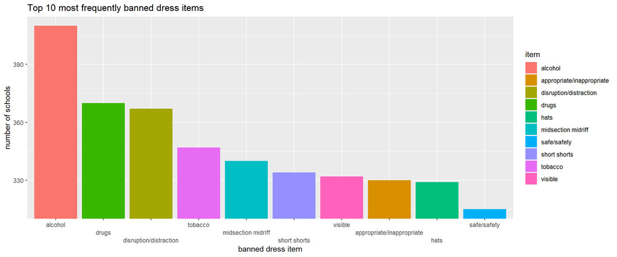

## Chart 2

Wordcloud comparing frequency of terms used to describe or justify banned items. The different text sizes correlate with the frequency of the term/phrase being used, with “disruption/distraction”, “safe/safety”, and “appropriate/innapropriate” being used the most. The most frequently used terms are all general terms and ambiguous in relation to clothing items.

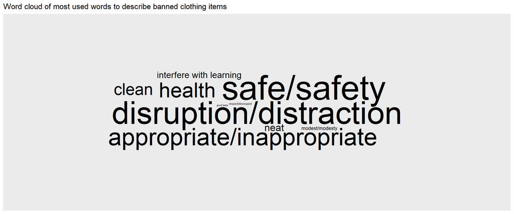

## Chart 3

Treemap intended to highlight the difference in frequency of items banned for male and female clothing, as well as for non-gendered clothing. The treemap shows the drastic difference between female and male banned items, with the female block being much larger.

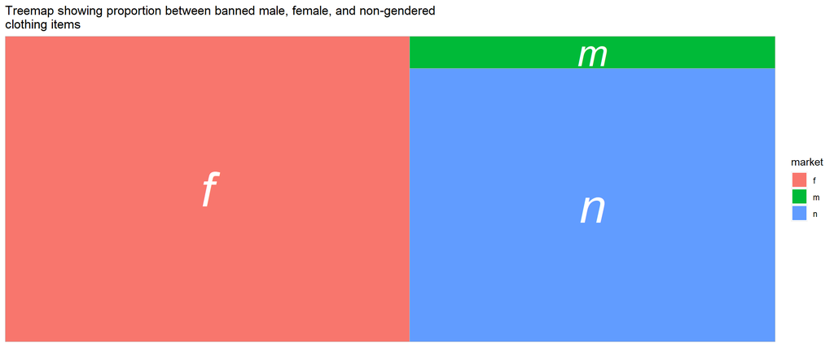